# Processamento de Linguagem Natural

Texto como dado

Wesley Galvão

# O problema

## Olist: a nota diz quanto, o texto diz por quê

**A pergunta da aula: do que reclamam os clientes da Olist?**

O objetivo é usar PLN para:

- transformar os comentários das avaliações em dados contáveis;
- comparar o que escrevem os clientes insatisfeitos e os satisfeitos;
- chegar às expressões que marcam as avaliações ruins: a primeira resposta.

## O escopo desta aula

[figure not shown]

Hoje, contar palavras e limpar o *corpus* para responder à pergunta. **Na próxima semana: representações vetoriais de texto**, que agrupam as avaliações pelo sentido.

## As avaliações da Olist

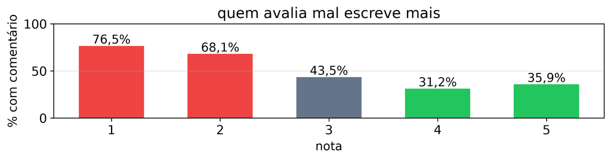

- 99.224 avaliações; **40.977** (41,3%) têm comentário. **76,5%** das notas 1 têm comentário, contra 35,9% das notas 5.
- Notas 1 e 2 são avaliações **ruins** (10.890 comentários); 4 e 5 são **boas** (26.530).

## Cinco avaliações, como estão no arquivo

nota 1fiz minha compra faz 30 dias e não recebi ainda meu produto.↵Precisa melhorar nas entregas

nota 3Embora tenha pago R$88,46 (2 relógios e frete) só recebi um. Espero q vcs averiguem e me informem. Continuo aguardando

nota 5Produto perfeito, entrega rápida. Estou satisfeitíssima. 👏🏽

nota 5Muito bom␣

nota 5MEU PRODUTO VEIO ERRADO.↵↵PAGUEI CASAL KING R$ 99,00 - NÂO CASAL PADRAO. QUERO TROCA URGENTE.

`↵` marca uma quebra de linha e `␣` um espaço sobrando no fim: na tela somem, no arquivo contam.

# Do texto ao token

## Corpus, token e vocabulário

**Corpus.** O conjunto de textos analisado: os 40.977 comentários da Olist.  
**Token.** Cada pedaço em que o texto é cortado para ser contado, em geral uma palavra.  
**Tipo.** Um token único: as repetições contam uma vez só. Os tipos do *corpus* formam o **vocabulário**.

[figure not shown]

## Stopwords

**Stopwords.** Palavras funcionais, muito frequentes e com pouco conteúdo próprio (“o”, “de”, “e”). Listas prontas, como a do NLTK, tiram essas palavras da contagem. A lista pode e deve ser customizada: “não” tem sentido próprio (Caseli e Nunes, 2026, cap. 4).

[figure not shown]

## Da sentença ao byte

**Unicode.** O padrão que dá um número a cada caractere de todas as escritas, emojis incluídos: o **ponto de código**, escrito U+ e o número em hexadecimal (é = U+00E9). O UTF-8 grava cada número em 1 a 4 bytes.  
**Grafema.** O caractere que o leitor vê na tela. Pode ser feito de mais de um ponto de código: 👍🏻 é o polegar (U+1F44D) mais o tom de pele (U+1F3FB).

[figure not shown]

## Regex: o que é

**Regex** (expressão regular) é um padrão que descreve um trecho de texto. O computador varre o texto e devolve cada trecho que casa com o padrão.

[figure not shown]

## Regex como régua de tokens

A régua mais simples é cortar nos espaços; cada passo seguinte é um regex que corrige um defeito do anterior.

12345quero encontrar

cortar em cada espaço

`texto.split(" ")`

sem regex: o método de string corta em cada caractere de espaço, e só nele

Embora tenha pago R$88,46 (2 relógios e frete) só recebi um. Espero q vcs averiguem e me informem. Continuo aguardando

fiz minha compra faz 30 dias e não recebi ainda meu produto.↵Precisa melhorar nas entregas

✗ ↵ não é espaço: “produto.↵Precisa” vira um token só**37.945** tipos no corpus

12345quero encontrar

tudo o que está entre espaços, tabs ou quebras de linha

`\S+`

um ou mais caracteres que não são espaço em branco (o mesmo que texto.split())

Embora tenha pago R$88,46 (2 relógios e frete) só recebi um. Espero q vcs averiguem e me informem. Continuo aguardando

Produto perfeito, entrega rápida. Estou satisfeitíssima. 👏🏽

✗ a pontuação gruda: “frete)” e “um.” viram tipos novos**35.098** tipos no corpus

12345quero encontrar

sequências de letras e dígitos, sem a pontuação

`\w+`

um ou mais caracteres de palavra: letra, dígito ou _

Embora tenha pago R$88,46 (2 relógios e frete) só recebi um. Espero q vcs averiguem e me informem. Continuo aguardando

Produto perfeito, entrega rápida. Estou satisfeitíssima. 👏🏽

✗ parte “R$88,46” em R, 88 e 46 e perde o emoji**20.219** tipos no corpus

12345quero encontrar

só palavras: sequências de letras, com acento

`[^\W\d_]+`

caractere de palavra que não é dígito nem _

Embora tenha pago R$88,46 (2 relógios e frete) só recebi um. Espero q vcs averiguem e me informem. Continuo aguardando

Produto perfeito, entrega rápida. Estou satisfeitíssima. 👏🏽

✗ os números somem: “88,46” e “2” ficam de fora**19.547** tipos no corpus

12345quero encontrar

valor em reais, número, palavra ou emoji, nessa ordem

`R\$\s?\d+(,\d+)*`dinheiro|`\d+(,\d+)*`número|`[^\W\d_]+`palavra|`emoji`emoji

a primeira alternativa que casa vence (o padrão completo também aceita URLs e hífens)

Embora tenha pago R$88,46 (2 relógios e frete) só recebi um. Espero q vcs averiguem e me informem. Continuo aguardando

Produto perfeito, entrega rápida. Estou satisfeitíssima. 👏🏽

✓ “R$88,46” e “👏🏽” ficam inteiros: a ordem decide**20.291** tipos no corpus

■ token bom■ token com defeitoficou de fora

## Três tokenizadores pré-treinados

[figure not shown]

NLTK e spaCy aplicam regras do português; o do GPT corta em pedaços aprendidos num corpus enorme.

## O vocabulário depende da régua

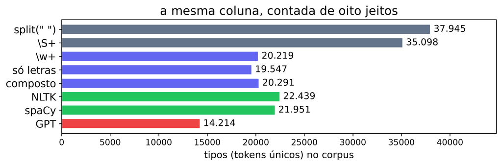

- Cortando em cada espaço, **37.945** tipos: “prazo”, “prazo.” e “prazo,” contam como três, e 4.875 tokens carregam uma quebra de linha. Com `\S+`, 35.098.
- Regex, regras do português (NLTK, spaCy) e GPT ficam entre 14 e 22 mil: cada um corta o texto num lugar diferente.

# O corpus em números

## Estatísticas do corpus

[figure not shown]

## Zipf: poucas palavras fazem quase todo o texto

[figure not shown]

**Lei de Zipf.** Ordenadas da mais usada para a menos usada, as palavras perdem frequência depressa e sempre do mesmo jeito, em qualquer língua e em qualquer *corpus*. Sem stopwords, o topo muda (“produto”, “recomendo”), mas a queda é a mesma: a 1.000ª aparece centenas de vezes menos que a 1ª.

## Zipf na prática

[figure not shown]

100 palavras fazem 62% do texto; três quartos do vocabulário somam menos de 4%. Os motivos de reclamação estão no meio.

# A primeira resposta

## As palavras das reclamações

**Do que reclamam os clientes?** Pares de palavras seguidas (*bigramas*) muito mais comuns nas avaliações ruins: a barra vermelha é a % das ruins que contêm o bigrama; a cinza, o mesmo nas boas.

[figure not shown]

**A entrega domina**: “não recebi”, “não chegou”, “até agora”.

## O que essa contagem ainda não sabe

- **“não recebi”** aparece em 1.769 mensagens e **“nao recebi”** em 266: no gráfico, são dois termos.
- “Muito bom” aparece no arquivo com **13 grafias** diferentes.
- 309 comentários entram mais de uma vez: a mesma avaliação ligada a vários pedidos.

É o assunto da segunda parte: higiene de *corpus*.

## Onde isso continua

- **Higiene de corpus**, a seguir: normalização, filtros, *matching* (duplicatas e grupos de reclamações parecidas) e dados pessoais. A mesma resposta, refeita no fim.
- **Próxima semana**: representações vetoriais. “atrasou”, “demorou” e “não chegou” contam separado aqui; *embeddings* agrupam pelo sentido.
- **Laboratório**: as réguas de regex, os três tokenizadores, as contagens, Zipf e os bigramas das ruins, em código.

## Referências

- Caseli, H. M.; Nunes, M. G. V. (org.). *Processamento de Linguagem Natural: Conceitos, Técnicas e Aplicações em Português*, 4ª ed. BPLN, 2026, cap. 4 (token e type, palavras funcionais, tokenização, normalização). brasileiraspln.com/livro-pln-4ed
- Jurafsky, D.; Martin, J. H. *Speech and Language Processing*, 3ª ed. (rascunho), cap. 2: palavras, tokens e expressões regulares.
- Zipf, G. K. *The Psycho-Biology of Language*. Houghton Mifflin, 1935.
- Sennrich, R.; Haddow, B.; Birch, A. *Neural Machine Translation of Rare Words with Subword Units*. ACL, 2016.
- Unicode Standard Annex #29, *Unicode Text Segmentation* (grafemas).
- Documentação: NLTK (`word_tokenize`, `stopwords`), spaCy (`pt_core_news_sm`), tiktoken (`o200k_base`).